# Lab 13: Soil MAG Community Analysis

# Data Preparation

This dataset contains MAGs collected from NEON soil metagenomes.  
Taxonomy and sample site IDs are used to evaluate microbial community structure.

```r
library(tidyverse)
library(vegan)

neon <- read_csv("~/Bio 478 Lab/NEON_soilMAGs_soilChem.csv") |>
  filter(!is.na(phylum))
```

# Distribution of MAGs Across Sites

Counting MAGs per site illustrates sampling depth differences and general variation in recovered genome counts.

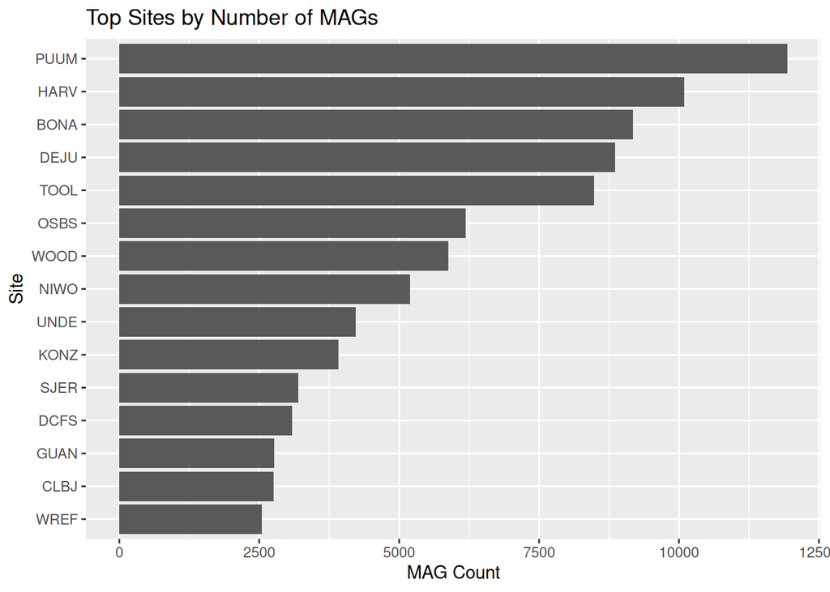

```r
neon |>
  count(site_ID, name = "n_MAGs") |>
  arrange(desc(n_MAGs)) |>
  slice_head(n = 15) |>
  ggplot(aes(x = reorder(site_ID, n_MAGs), y = n_MAGs)) +
  geom_col() +
  coord_flip() +
  xlab("Site") +
  ylab("MAG Count") +
  ggtitle("Top Sites by Number of MAGs")
```

# Dominant Phyla Across All Sites

Phylum frequency highlights which broad microbial lineages are most detected in the MAG dataset.

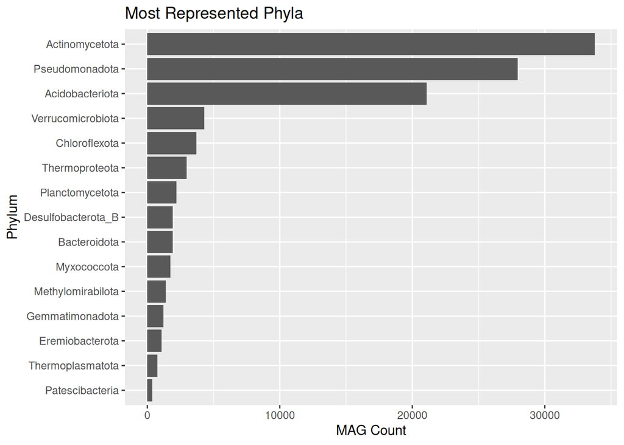

```r
neon |>
  count(phylum, name = "n_MAGs") |>
  arrange(desc(n_MAGs)) |>
  slice_head(n = 15) |>
  ggplot(aes(x = reorder(phylum, n_MAGs), y = n_MAGs)) +
  geom_col() +
  coord_flip() +
  xlab("Phylum") +
  ylab("MAG Count") +
  ggtitle("Most Represented Phyla")
```

# Dominant Classes Across All Sites

Class-level patterns refine broad phylum profiles and show more detailed taxonomy differences.

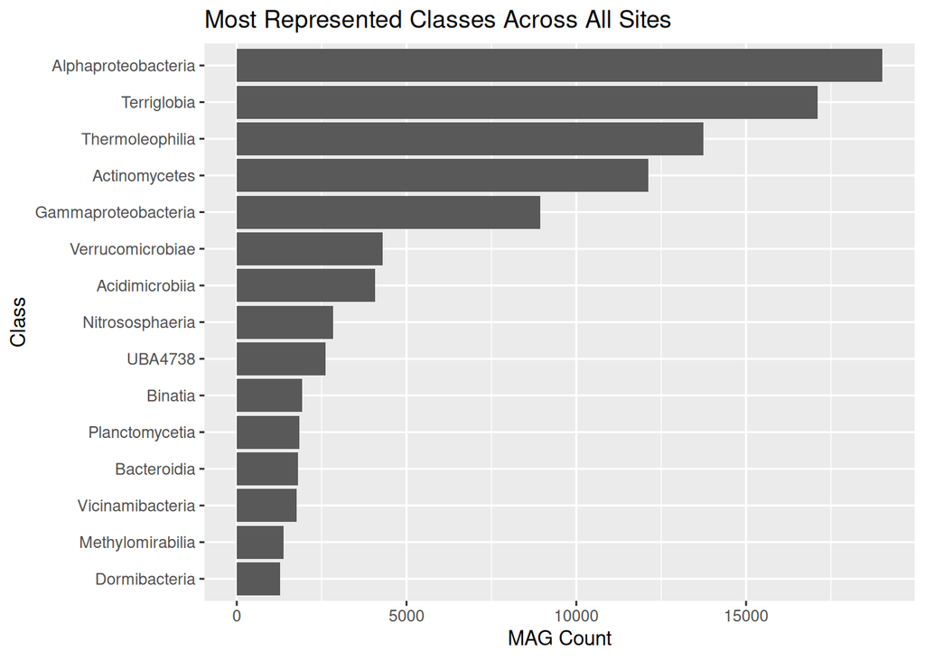

```r
if ("class" %in% names(neon)) {
  neon |>
    filter(!is.na(class)) |>
    count(class, name = "n_MAGs") |>
    arrange(desc(n_MAGs)) |>
    slice_head(n = 15) |>
    ggplot(aes(x = reorder(class, n_MAGs), y = n_MAGs)) +
    geom_col() +
    coord_flip() +
    xlab("Class") +
    ylab("MAG Count") +
    ggtitle("Most Represented Classes Across All Sites")
}
```

# Phylum Composition by Site

Relative phylum proportions show taxonomic differences among sampling locations.  
MAG count per phylum serves as a proxy for presence because read abundance data are not included in this dataset.

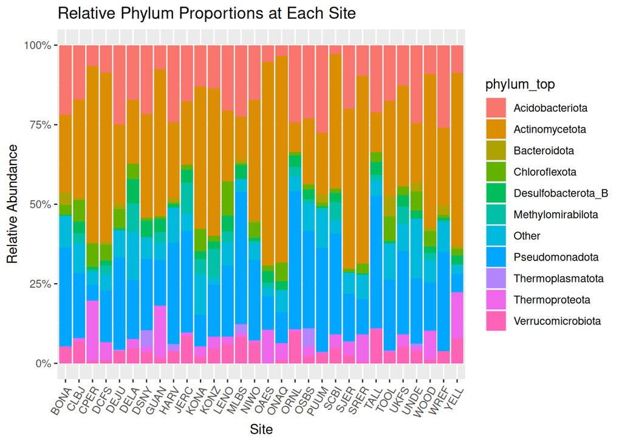

```r
phylum_rel2 |>
  ggplot(aes(x = site_ID, y = rel_abundance, fill = phylum_top)) +
  geom_col() +
  xlab("Site") +
  ylab("Relative Abundance") +
  ggtitle("Relative Phylum Proportions at Each Site") +
  scale_y_continuous(labels = scales::percent_format(accuracy = 1)) +
  theme(axis.text.x = element_text(angle = 60, hjust = 1))
```

# Heatmap of Phylum Counts by Site

This heatmap visualizes absolute phylum-level presence by site.

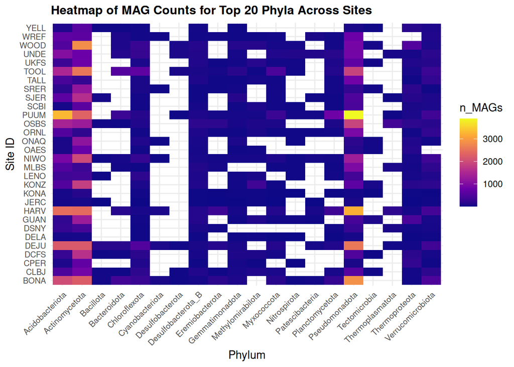

```r
# 按 phylum 总数排序，挑前20个最常见的门
top20 <- neon |>
  count(phylum) |>
  arrange(desc(n)) |>
  slice_head(n = 20) |>
  pull(phylum)

heat_df <- neon |>
  filter(phylum %in% top20) |>
  count(site_ID, phylum, name = "n_MAGs")

ggplot(heat_df, aes(x = phylum,
                    y = site_ID,
                    fill = n_MAGs)) +
  geom_tile() +
  scale_fill_viridis_c(
    option = "C",
    direction = 1,
    na.value = "white"
  ) +
  xlab("Phylum") +
  ylab("Site ID") +
  ggtitle("Heatmap of MAG Counts for Top 20 Phyla Across Sites") +
  theme_minimal() +
  theme(
    axis.text.x = element_text(
      angle = 45,
      hjust = 1,
      size = 8
    ),
    axis.text.y = element_text(size = 8),
    plot.title = element_text(size = 12, face = "bold")
  )
```

# Alpha Diversity of MAG Communities

Alpha diversity describes within-site diversity.  
Richness counts detected phyla, while the Shannon index increases as both richness and evenness rise.

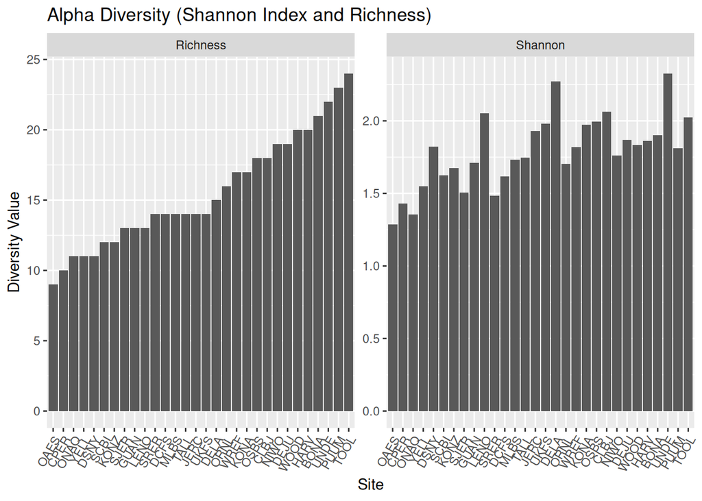

```r
alpha_long |>
  ggplot(aes(x = reorder(site_ID, Value), y = Value)) +
  geom_col() +
  facet_wrap(~ Metric, scales = "free_y") +
  xlab("Site") +
  ylab("Diversity Value") +
  ggtitle("Alpha Diversity (Shannon Index and Richness)") +
  theme(axis.text.x = element_text(angle = 60, hjust = 1))
```

# Shannon Diversity vs Soil pH

Shannon diversity is compared to soil pH to examine possible environmental influence.

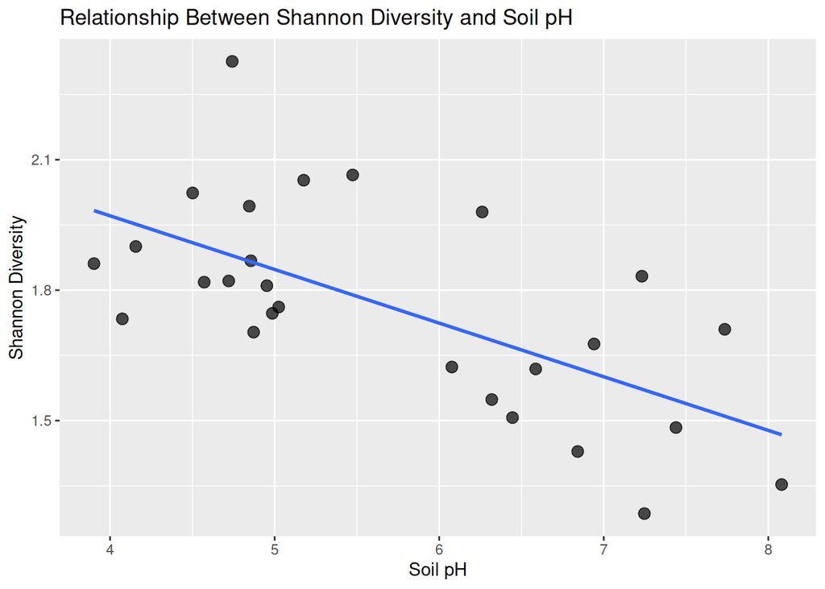

```r
ggplot(alpha_env, aes(x = soil_pH, y = Shannon)) +
  geom_point(size = 3, alpha = 0.7) +
  geom_smooth(method = "lm", se = FALSE) +
  xlab("Soil pH") +
  ylab("Shannon Diversity") +
  ggtitle("Relationship Between Shannon Diversity and Soil pH")
```

# Richness vs Soil Moisture

Richness is plotted against soil moisture to explore another environmental gradient.

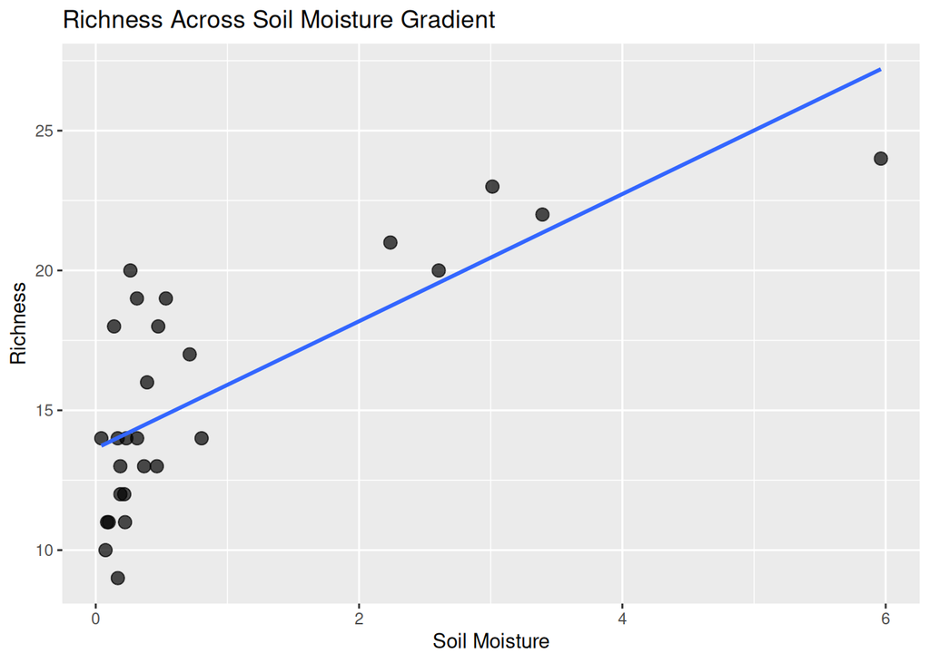

```r
ggplot(alpha_env, aes(x = moisture, y = Richness)) +
  geom_point(size = 3, alpha = 0.7) +
  geom_smooth(method = "lm", se = FALSE) +
  xlab("Soil Moisture") +
  ylab("Richness") +
  ggtitle("Richness Across Soil Moisture Gradient")
```

# Bray–Curtis Distance Between Sites

Bray–Curtis measures compositional dissimilarity (0 = identical, 1 = no shared taxa).  
Site clustering and heatmaps reveal similarities in microbial structure.

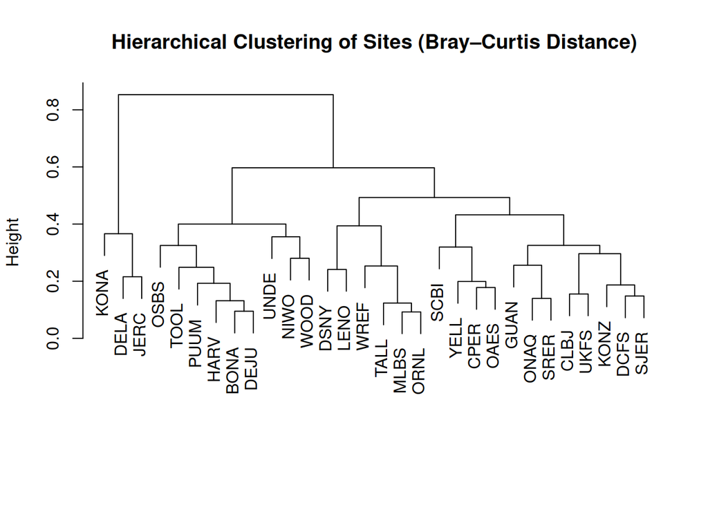

```r
plot(
  hclust(bray_dist, method = "average"),
  labels = comm_matrix$site_ID,
  main = "Hierarchical Clustering of Sites (Bray–Curtis Distance)",
  xlab = "", sub = ""
)
```

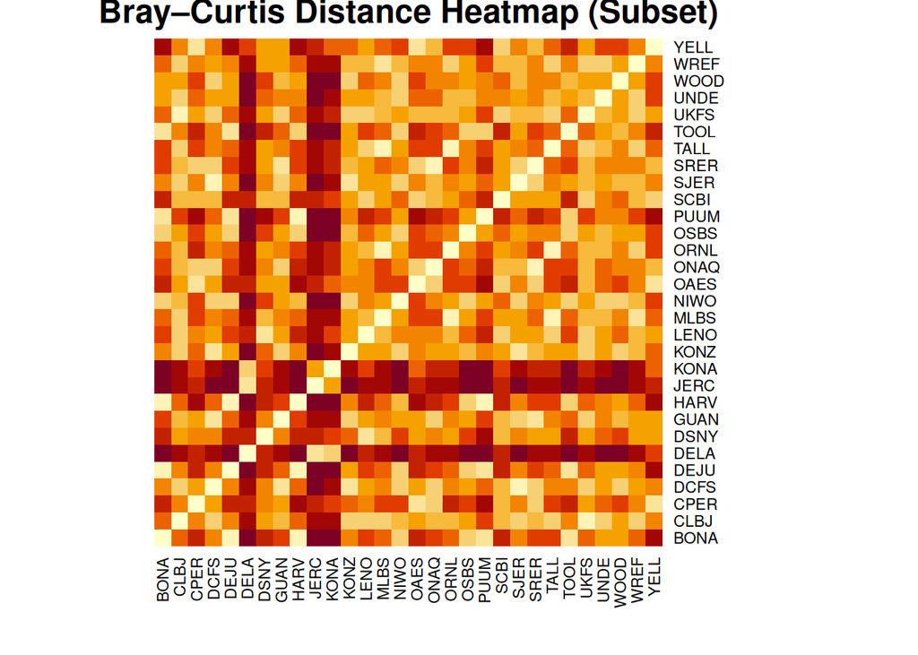

```r
n_show <- min(30, nrow(comm_only))
bray_mat <- as.matrix(bray_dist)[1:n_show, 1:n_show]
rownames(bray_mat) <- comm_matrix$site_ID[1:n_show]
colnames(bray_mat) <- comm_matrix$site_ID[1:n_show]

heatmap(
  bray_mat,
  Rowv = NA, Colv = NA,
  scale = "none",
  main = "Bray–Curtis Distance Heatmap (Subset)"
)
```

# PCA Ordination Based on Phylum Counts

PCA provides a linear ordination alternative to NMDS.

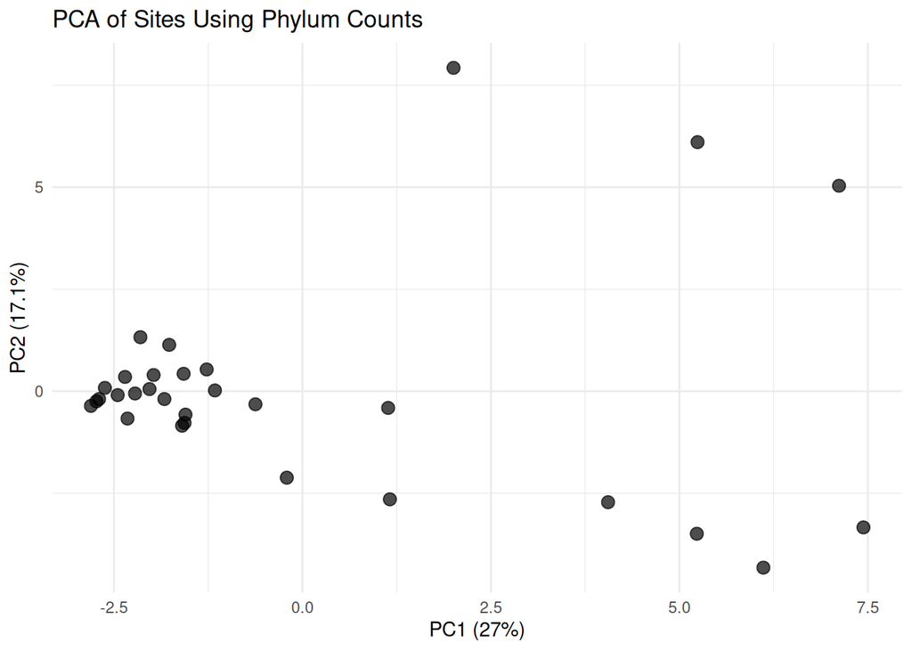

```r
ggplot(pca_df, aes(x = PC1, y = PC2)) +
  geom_point(size = 3, alpha = 0.7) +
  xlab(paste0("PC1 (", pc1_var, "%)")) +
  ylab(paste0("PC2 (", pc2_var, "%)")) +
  ggtitle("PCA of Sites Using Phylum Counts") +
  theme_minimal()
```

# NMDS Ordination of Sites

NMDS projects multidimensional distance data into two axes.  
Samples positioned closely contain more similar MAG composition.

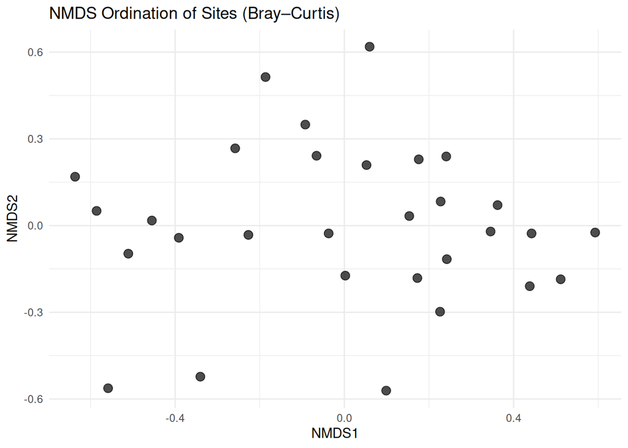

```r
ggplot(ord_df, aes(x = MDS1, y = MDS2)) +
  geom_point(size = 3, alpha = 0.7) +
  xlab("NMDS1") +
  ylab("NMDS2") +
  ggtitle("NMDS Ordination of Sites (Bray–Curtis)") +
  theme_minimal()
```